# Introduction to dsfbnine

```r
devtools::install_github("nineluijendijk/dsfbnine")
library(dsfbnine)
```

## Package contents

### Dataset measlesdata

The [{dsfbnine} package](https://github.com/nineluijendijk/dsfbnine) contains some functions to help me with my data analysis and one cleaned dataset `measlesdata`. It contains data on measles cases and population numbers in EU countries from 2018 and 2019. The dataset loads as a dataframe with 744 rows and 8 variables. It is available via lazy-loading, meaning columns can be accessed as follows:

```r
measlesdata$cases %>% head(n = 20)
```

```
##  [1]  7  5 15 17 12  6  1  3  6  0  4  1  1  6  9 11 24 22  3 11
```

### Function dataSummarizer()

The function `dataSummarizer()` calculates the sum, mean, median and standard deviation of data, grouped by a given argument:

```r
dataSummarizer(measlesdata, groupBy = c("CountryName", "year")) %>% head(n = 10)
```

```
## # A tibble: 10 × 6
## # Groups:   CountryName [7]
##    CountryName year  total  mean median standarddeviation
##    <chr>       <chr> <dbl> <dbl>  <dbl>             <dbl>
##  1 EU/EEA      2019  13207 1101. 1012.              783.
##  2 EU/EEA      2018  12352 1029.  959               687.
##  3 France      2018   2913  243.  136               252.
##  4 France      2019   2636  220.  166.              176.
##  5 Italy       2018   2517  210.  170               155.
##  6 Greece      2018   2293  191.   96.5             211.
##  7 Romania     2019   1706  142.  111                72.8
##  8 Italy       2019   1626  136.  162               106.
##  9 Poland      2019   1423  119.   82.5             121.
## 10 Bulgaria    2019   1235  103.   46.5             110.
```

### Function illnessPlot()

The function `illnessPlot()` generates a graph showing illness numbers, specifically COVID-19 numbers from an [ECDC](https://www.ecdc.europa.eu/en/covid-19/data) dataset, used in [Chapter 6](https://nineluijendijk.github.io/parameterized.html) of my portfolio. The same code was used to generate 4 different plots, to fix this issue `illnessPlot()` was created.

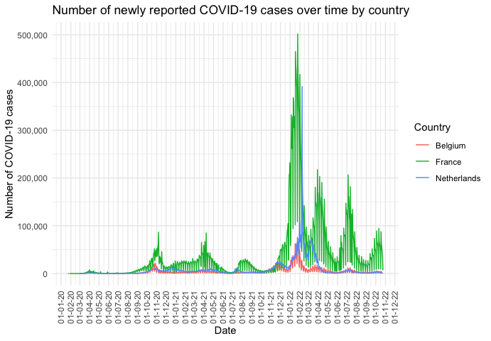

Example illness plot.

```r
coviddata <- read.csv(here::here("inst/extdata/datacovid.csv")) #load the data
illnessPlot(coviddata, countries = c("Netherlands", "Belgium", "France"), years = 2020:2022, parameter = cases)
```

### Function fastaImporter.R

The function `fastaImporter()` can be used to import FASTA sequences by entering their GenBank Identifiers. The imported sequences will be stored in an object of class “DNAbin”.

```r
dna <- fastaImporter(here::here("inst/extdata/GenBankIDs2.txt"))
dna
```

```
## 16 DNA sequences in binary format stored in a list.
##
## Mean sequence length: 16523.81
##    Shortest sequence: 16264
##     Longest sequence: 17062
##
## Labels:
## KF914213.1 Gorilla beringei graueri mitochondrion, complete ...
## NC_011120.1 Gorilla gorilla gorilla mitochondrion, complete ...
## GU170821.1 Homo sapiens isolate NS07 mitochondrion, complete...
## HM015213.1 Pan paniscus isolate PP25 mitochondrion, complete...
## NC_001643.1 Pan troglodytes mitochondrion, complete genome
## NC_002083.1 Pongo abelii mitochondrion, complete genome
## ...
##
## Base composition:
##     a     c     g     t
## 0.314 0.299 0.131 0.256
## (Total: 264.38 kb)
```

### Function gotermAnalysis()

The function `gotermAnalysis()` was written specifically to help with my analysis of RNA-sequencing data, which is why there are many different parameters to be set: changing just 1 can completely change the results. The function performs a GO-term enrichment analysis. The output of this function can be used in the next function `gotermPlot()` as well.

```r
DESeqresults <- readRDS(here::here("inst/extdata/dge_results")) #load the data object of class "DESeqResults"

gotermAnalysis_results <- gotermAnalysis(DESeqresults)
```

### Function gotermPlot()

The function `gotermPlot()` is an extension to the previous `gotermAnalysis()` function, generating a figure containing the most abundant GO-terms.

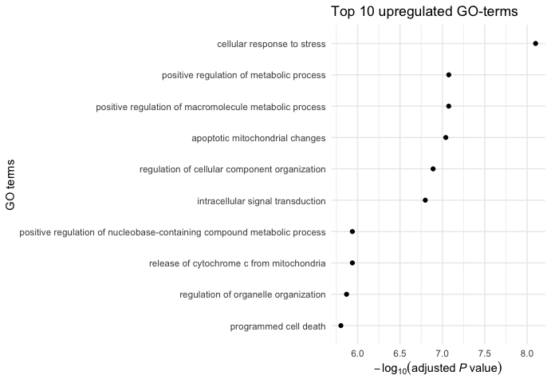

Example GO-term plot.

```r
gotermAnalysis_results <- readRDS(here::here("inst/extdata/gotermAnalysis_results"))

gotermPlot(gotermAnalysis_results, topamount = 10, plot_title = "Top 10 upregulated GO-terms")
```